# Prosper Loan Data Exploration by Peter Carsten Petersen

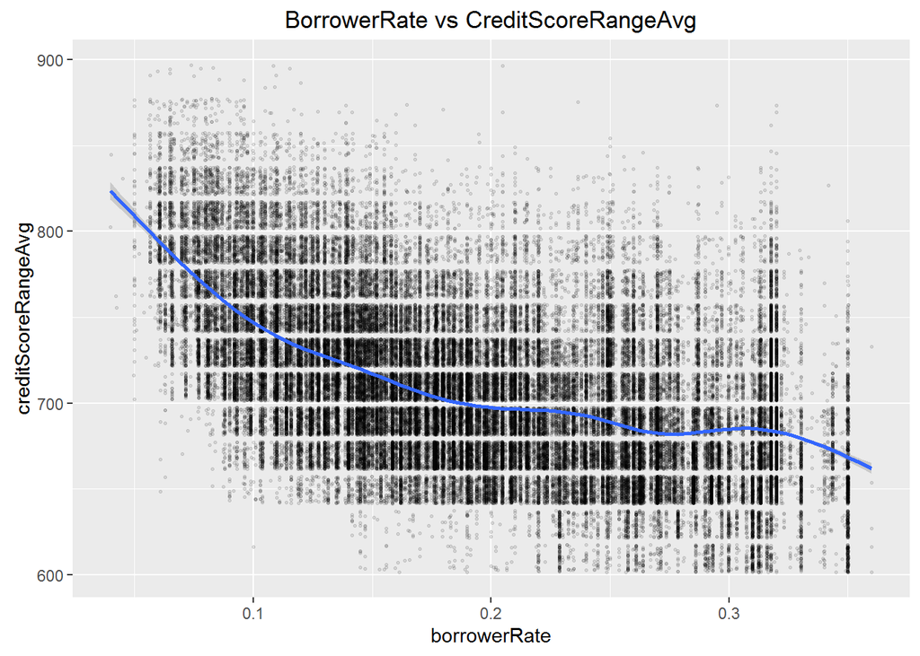

borrowerRate vs. creditScoreAvg however is showing a far less liniar relationsship although trend of lower creditScoreAvg = higher borrowerRate is visible.

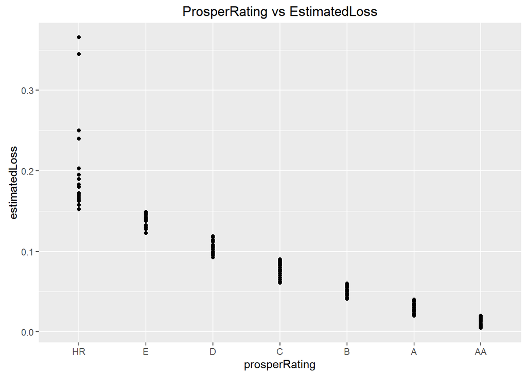

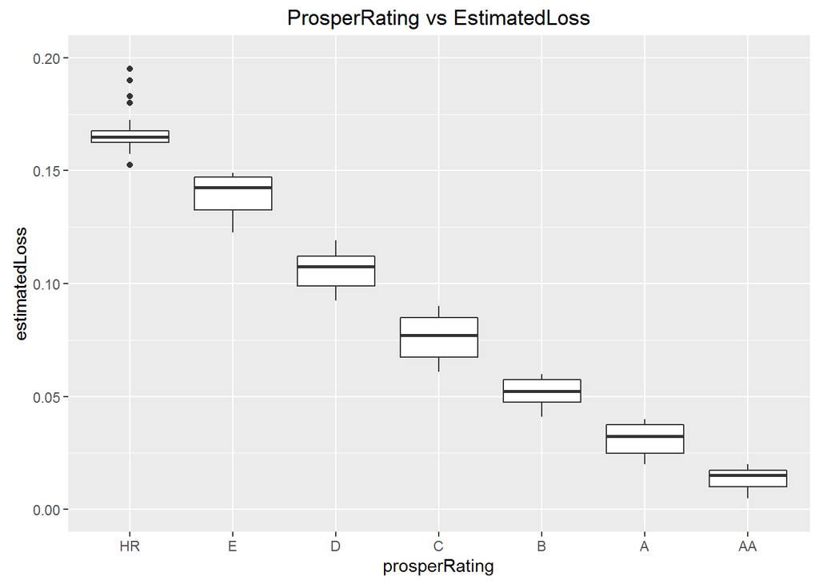

```
## [1] -0.9641819
```

Finally please note the almost perfect relationsship between prosperRating and estimatedLoss with almost no overlap between prosperRating/estimatedLoss pairs, and only outliers in the “HR” prosperRating.

# Bivariate Analysis

### Talk about some of the relationships you observed in this part of the investigation. How did the feature(s) of interest vary with other features in the dataset?

BorrowerRate correlates strongly with prosperRating and to a lesser extent with prosperScore and creditScoreAvg.

As prosperRating decreases (i.e. from Best to worst) the borrowerRate increases, same relationship with prosperScore and creditScoreAvg. Relationship between borrowerRate and prosperRating seems liniar.

### Did you observe any interesting relationships between the other features (not the main feature(s) of interest)?

Further interesting relationships are seen between prosperScore and prosperRating as well as between estimated loss and prosperScore.

Also between borrowerRate and prosperScore, showing unusual and counter logical relationsship across prosperScore, indicating that one or more other variables are needed to explain this relationsship. A further investigation on prosper website clarifies this, as stated:

Prosper uses both the custom score (prosperScore) and the credit reporting agency score (creditScoreRangeAvg) together to assess the borrower’s level of risk and determine estimated loss rates (estimatedLoss).

### What was the strongest relationship you found?

Relationship between borrowerRate and estimatedLoss as well as between prosperRating and estimatedLoss are extremely strong, so strong in fact that i suspect that one is a direct product of the other.

This relationship between borrowerRate/estimatedLoss/prosperRating as well as prosperScore will be investigated further in the next section.

# Multivariate Plots Section

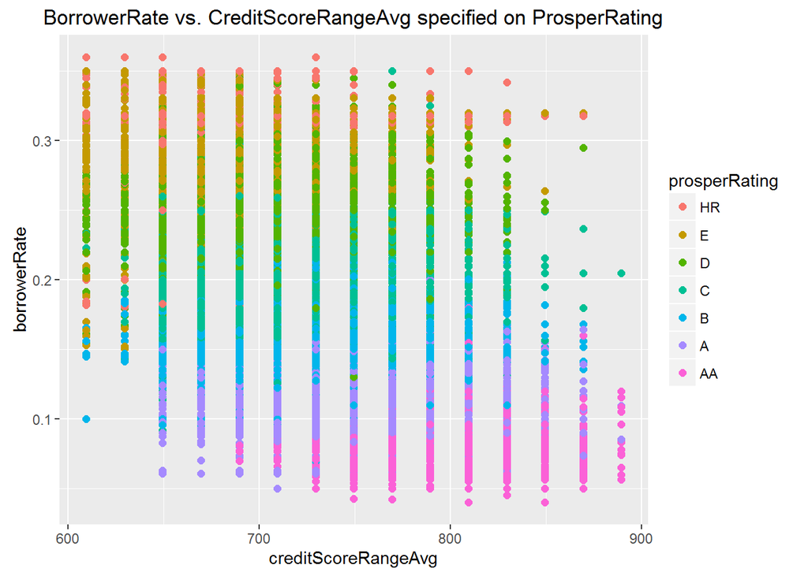

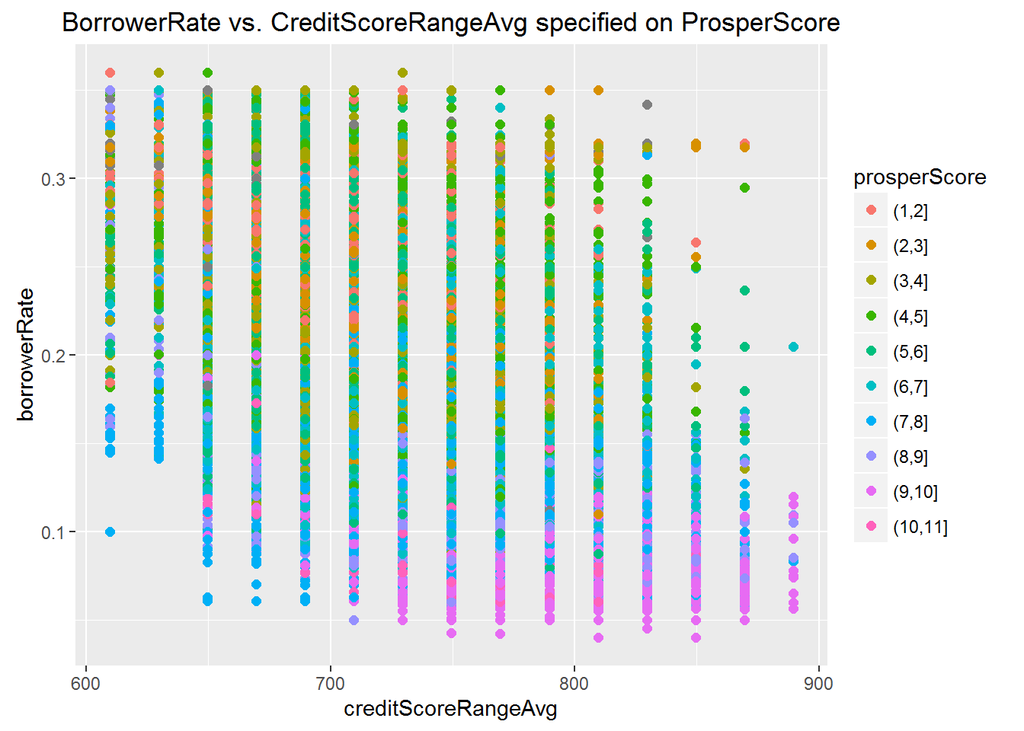

Following the finding in the Bi-variate section I am looking for relationsships, between the main variables borrowerRate/creditScoreRangeAvg and specified via prosperRating or prosperScore. While there seems to be some relationship between these variables, it is only highlevel and not estimated very strong, next I will exchange estimatedLoss for borrowerRate and do same plotting.

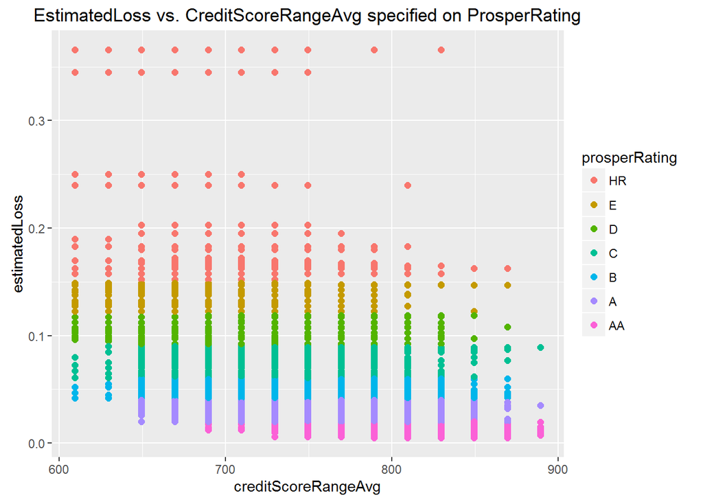

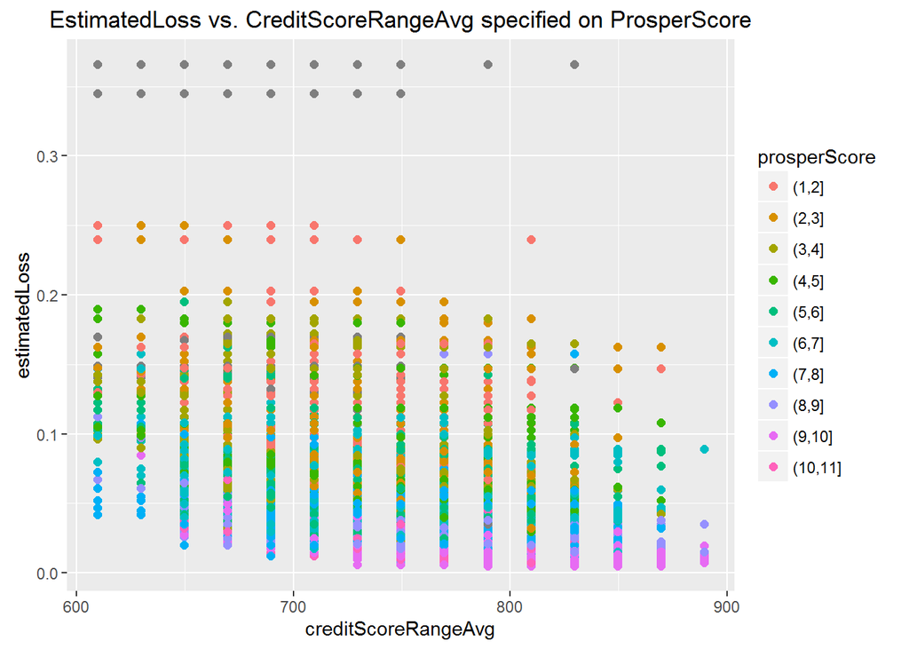

Building further on this we can look at the relationship on a Mean basis

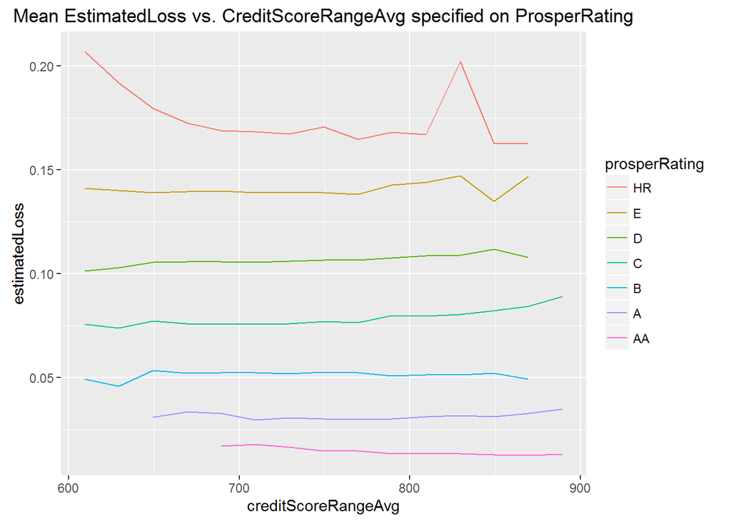

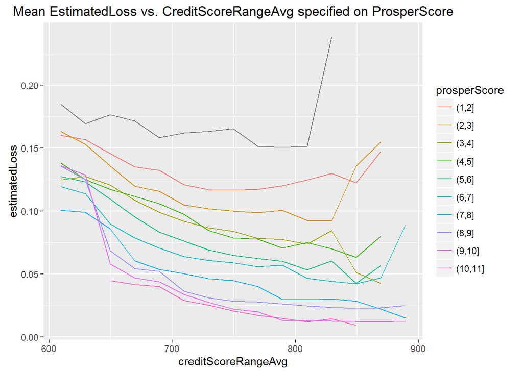

This further illustrates the strong relationsship between estimatedLoss/creditScoreRangeAvg and prosperRating/prosperScore, but there are some un-expected increases at the highest creditScoreRangeAvg. Perhaps including both prosperRating and prosperScore in analysis, as well as all 5 variables will show a clearer picture.

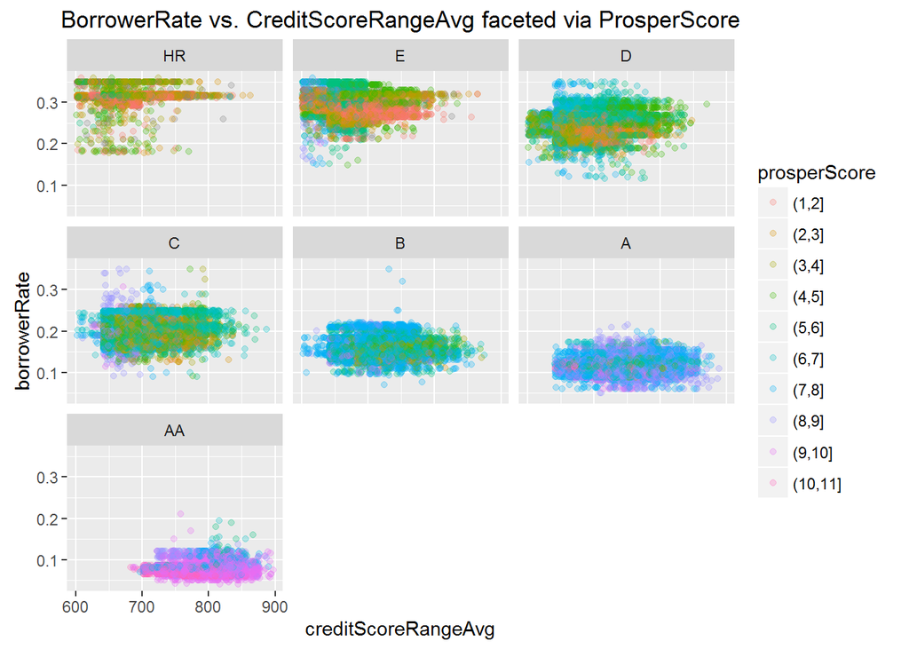

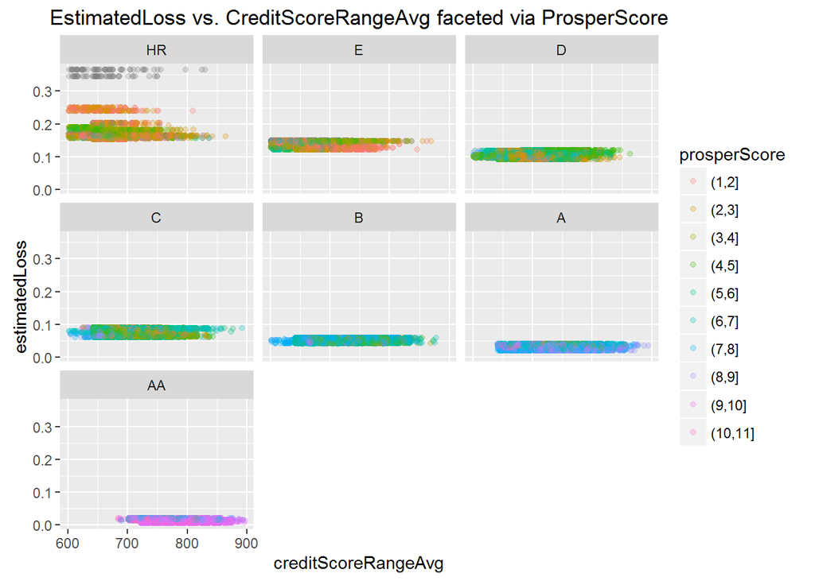

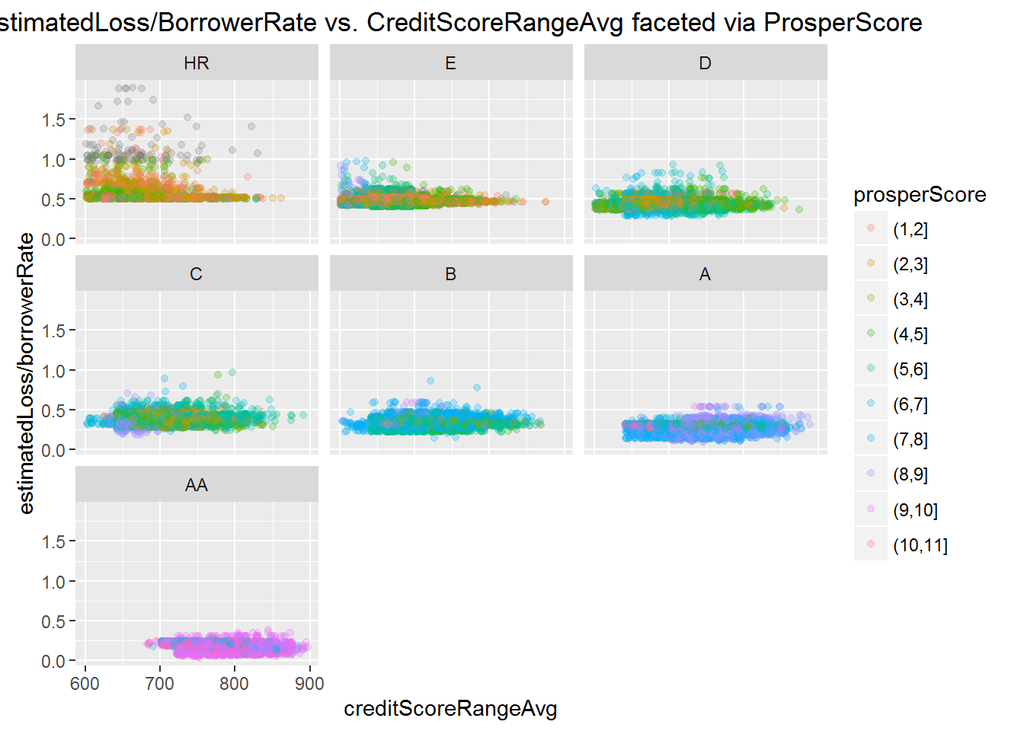

This definately reuslted in a better fit. For all three options, the high variability is evident in the “HR” bucket and improved estimatedLoss/borrowerRate highly visible when improving score/rating and creditScore. Especially the last chart including all 5 variables seems to be a good illustration of how the 5 variables are connected.

# Multivariate Analysis

### Talk about some of the relationships you observed in this part of the investigation. Were there features that strengthened each other in terms of looking at your feature(s) of interest?

Drawing on the insights from the bi-variate section, it was found, when including all 5 variables, a strong connected relationship, this is somewhat expected in financial loan data, as both borrower and lender will have many other options to lend/invest and consistency/transparency is required.

### Were there any interesting or surprising interactions between features?

It was noted that no combination of borrowerRate vs prosperRating/prosperScore/creditScoreRangeAvg, nor estimateLoss vs prosperRating/prosperScore/creditScoreRangeAvg resulted in a solid relationsship which could reasonably be assumed a good fit for a predictive model, it takes a combination of all 5.

Variability of estimatedLoss/borrowerRate increases with weakening of prosperScore/prosperRating.

### OPTIONAL: Did you create any models with your dataset? Discuss the strengths and limitations of your model.

No models created, but there seems to be a good chance that building a model using variables estimatedLoss/borrowerRate/creditScoreRangeAvg/prosperRating/prosperScore, would result in a tool to determine if loan offered is on good terms and/or a resonable risk/reward investment.

# Final Plots and Summary

### Plot One

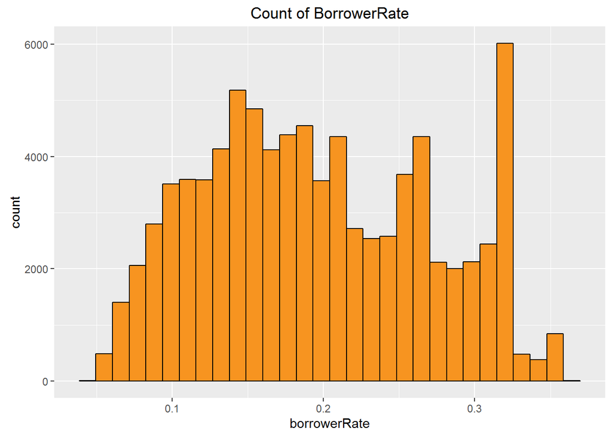

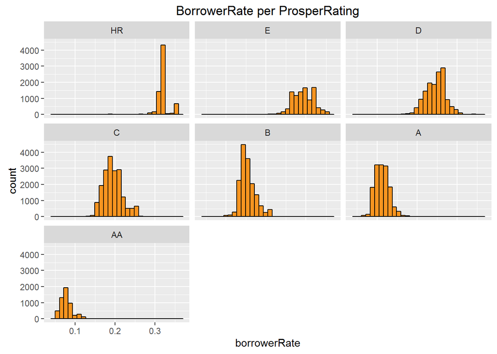

### Description One

BorrowerRates is between normal and Bi-modal distribution. Faceting this with ProsperRating we can see that the BorrowerRate peak > 0.3 is due to a heavy count of loans with a “HR” prosperRating (HR = High Risk)

### Plot Two

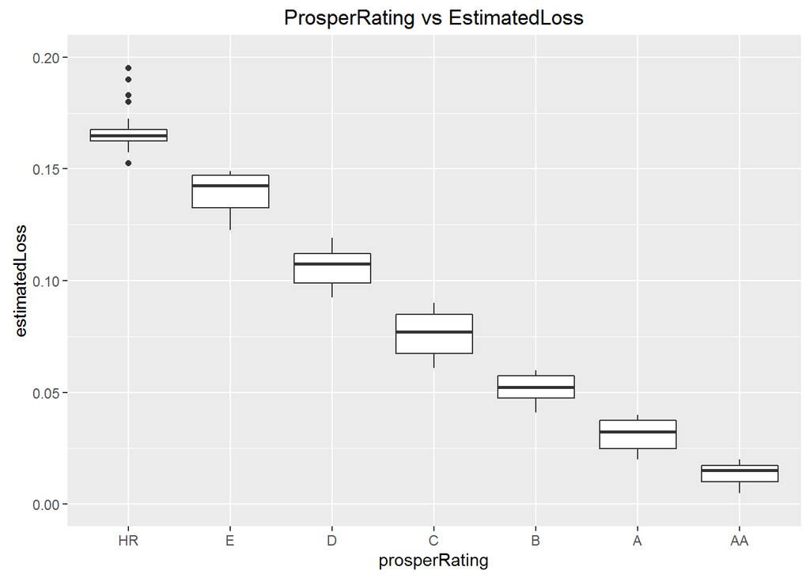

### Description Two

ProsperRating and EstimatedLoss are almost perfectly correlated with no overlap and very few outliers, showing a probable deliberate and systemic relationsship between these 2 variables.

### Plot Three

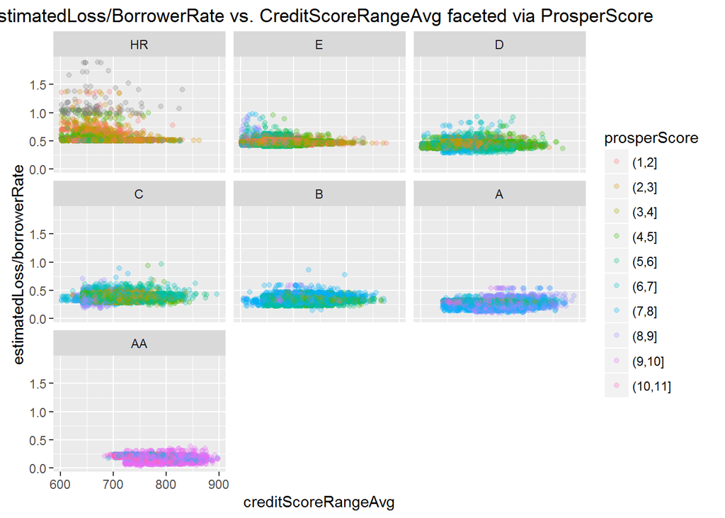

### Description Three

Building further on analysis and insights from univariate and bi-variate analysis, we arrive at a decent illustration hightlighting the consistency across records and the chosen variables, which is expected in financial loan records. I.e. a very clear relationship showing that the lower the CreditRatingScoreAvg/ProsperScore/ProsperRating the higher the estimatedLoss/borrowerRatio. Also as ProsperRating/creditScoreRangeAvg improves (rightshift in charts and data distribution) the color changes towards better prosperScore and lower ratio of estimatedLoss/borrowerRate.

# Reflection

the prosperloan dataset includes information for 113,937 records with 81 variables per record. I choose to limit this to 84,853 records removing all data which was from before July 2009, where the business model changed significantly and most complete and consistent dataset is post July 2009. From these 84,853 i choose 13 variables which were reduced to 12, as 2 of the 13 chosen variables were averaged into 1.

From this data subset I first analyzed each variable individually, to find the structure and distribution of variables, and following this looked at the correlation between pairs of data. It was determined that of the chosen variables most interest is on borrowerRate and estimatedLoss. A number of other variables were quickly determined to be of less interest and with very little impact/correlation on the main variables (EmploymentStatus/Term/ListingCategory/isBorrowerHomeowner/LoanStatus).

There were a number of strong relationsships between main variables and rating variables(ProsperScore/ProsperRating/CreditScoreRating) from 0.51 to 0.96, which were further investigated and resulting finally in a 5 variable overview showing a highly connected as well as expected relationsship. I.e from a borrowerRate there seems to a predictable relationship between actual rate/variability vs. the indivual/combined scores/rating, the same relationship from an EstimatedLoss viewpoint.

There were 81 variables in the original dataset and this analysis has been done on only 13, there is therefore a risk that data from the remaining 68 variables, would reveal insights that could discount or even dissprove the findings from the analysis on chosen variables. Analysis could therefore be improved/strengthen via include further variables.

It seems likely given the analysis that a predictive model could be built using the 5 variables BorrowerRate/EstimatedLoss/CreditScoreRangeAvg/ProsperScore/ProsperRating, which could assist potential borrower in determening if borrowerRate offered is fair and consistent with peers, and assist potential loan investors in assesing the risk/reward profil on loan investment.

# References

- www.wikipedia.org//wiki/Prosper_Marketplace
- www.prosper.com